# Исследование юнит-экономики мобильной игры Mines & Moles

Unit Economics Audit: Mines & Moles Mobile Game

## Цель проекта

Провести расчёт и анализ ключевых метрик: LTV, CAC, ROI, ARPPU и Retention Rate — и составить заключение о текущем состоянии юнит-экономики приложения.

## План проекта

1. Подготовка данных
2. Расчет, визуализация и когортный анализ ключевых финансовых метрик
3. Оценка окупаемости бизнеса

## Описание данных

**mm_game_users.csv — информация о пользователях**

- device_id — уникальный ID устройства
- install_time — дата и время установки игры
- country_code — код страны (например, RU, AZ)
- traffic_type — тип трафика (paid,organic)
- platform — ОС устройства (ios, android)
- source — источник привлечения
- campaign — название рекламной кампании
- user_id — уникальный ID пользователя

**mm_game_events.csv — события пользователей в игре**

- device_id — ID устройства
- session_id — ID сессии
- time — дата и время события
- event_name — событие запуска игры

**mm_game_transactions.csv — данные о транзакциях пользователей**

- device_id — уникальный идентификатор устройства
- session_id — идентификатор игровой сессии
- transaction_id — уникальный ID транзакции
- time — дата и время покупки
- payment_type — способ оплаты (bank_card, paypal, game_wallet)
- item_name — название товара (например, chest_1, coin_pack_2)
- price — стоимость товара
- status — статус транзакции (success, failed)

**mm_game_marketing_costs.csv — затраты на маркетинг по месяцам и каналам**

- month — месяц в формате YYYY-MM
- source — рекламный источник (например, google, yandex, youtube)
- traffic_type — тип трафика (paid, organic, referral)
- marketing_costs — затраты на маркетинг

## Подготовка данных

### Загрузка библиотек

```python
# Загружаем библиотеку Pandas
import pandas as pd
```

```python
# Загружаем библиотеки для визуализации данных
import matplotlib.pyplot as plt
import matplotlib.colors as mcolors
import seaborn as sns
```

```python
# Уменьшение разрешения DPI для графиков
plt.rcParams['figure.dpi'] = 72
```

```python
## Палитра
cmap = mcolors.LinearSegmentedColormap.from_list('green_red', ['#FF3333', '#FFFF66', '#4C9900'], N=100)
```

```python
pd.set_option('display.max_columns', None)  # Отображать все столбцы
pd.set_option('display.expand_frame_repr', False)  # Отключить перенос строк
```

### Загрузка данных

```python
# Выгружаем данные из файла `.csv` в датафрейм
try:
    #пробуем загрузить
    df_users = pd.read_csv('datasets/mm_game_users.csv')
    display('Данные успешно загружены')
except:
    # если не получилось
    display('Ошибка при загрузке файла')
```

```
'Данные успешно загружены'
```

```python
df_users.head()
```

|  | device_id | install_time | country_code | traffic_type | platform | source | campaign | user_id |
| --- | --- | --- | --- | --- | --- | --- | --- | --- |
| 0 | bd8faa44-01d5-4fac-8e58-102ef16d72b6 | 2024-01-23 13:09:52 | AZ | paid | ios | youtube | yt2 | 1.0 |
| 1 | 788cdde7-aa57-41f1-ac42-402ed9fa1b47 | 2024-01-05 18:21:35 | RU | organic | ios | direct_app_download | NaN | 3.0 |
| 2 | f1842785-15e9-4fda-9b2d-5ffdcceae78b | 2024-01-02 10:42:57 | RU | paid | android | google | g2 | 4.0 |
| 3 | 26f430d8-841c-4944-9f6d-2262a1d64787 | 2024-01-02 21:59:31 | RU | organic | ios | direct_app_download | NaN | 5.0 |
| 4 | ace4f666-c8ac-45b7-a0c1-e9f3dad48ab1 | 2024-01-21 19:29:42 | BY | organic | ios | direct_app_download | NaN | NaN |

```python
try:
    df_events = pd.read_csv('datasets/mm_game_events.csv')
    display('Данные успешно загружены')
except:
    display('Ошибка при загрузке файла')
```

```
'Данные успешно загружены'
```

```python
df_events.head()
```

|  | device_id | session_id | time | event_name |
| --- | --- | --- | --- | --- |
| 0 | ebd6c0a6-5a0a-4ea4-8f36-48771c983b1a | 1 | 2024-01-01 | app_start |
| 1 | ebd6c0a6-5a0a-4ea4-8f36-48771c983b1a | 2 | 2024-01-02 | app_start |
| 2 | ebd6c0a6-5a0a-4ea4-8f36-48771c983b1a | 3 | 2024-01-02 | app_start |
| 3 | ebd6c0a6-5a0a-4ea4-8f36-48771c983b1a | 4 | 2024-01-04 | app_start |
| 4 | ebd6c0a6-5a0a-4ea4-8f36-48771c983b1a | 5 | 2024-01-04 | app_start |

```python
try:
    df_transactions = pd.read_csv('datasets/mm_game_transactions.csv')
    display('Данные успешно загружены')
except:
    display('Ошибка при загрузке файла')
```

```
'Данные успешно загружены'
```

```python
 df_transactions.head()
```

|  | device_id | session_id | transaction_id | time | payment_type | item_name | price | status |
| --- | --- | --- | --- | --- | --- | --- | --- | --- |
| 0 | 0000614f-d87f-4b5b-a082-d86e72c22696 | 14 | 210588 | 2024-08-25 18:19:08 | paypal | chest_1 | 22 | failed |
| 1 | 0000614f-d87f-4b5b-a082-d86e72c22696 | 30 | 160059 | 2024-12-19 04:59:01 | bank_card | coin_pack_2 | 25 | success |
| 2 | 002250f4-c829-4760-af70-b53d75986d2d | 15 | 630387 | 2024-09-29 18:12:37 | bank_card | chest_1 | 22 | success |
| 3 | 002250f4-c829-4760-af70-b53d75986d2d | 31 | 874370 | 2024-10-26 13:55:40 | game_wallet | chest_1 | 22 | success |
| 4 | 002250f4-c829-4760-af70-b53d75986d2d | 33 | 623694 | 2024-11-02 01:55:05 | bank_card | skin_bundle_1 | 14 | success |

```python
try:
    df_marketing_costs = pd.read_csv('datasets/mm_game_marketing_costs.csv')
    display('Данные успешно загружены')
except:
    display('Ошибка при загрузке файла')
```

```
'Данные успешно загружены'
```

```python
df_marketing_costs.head()
```

|  | month | source | traffic_type | marketing_costs |
| --- | --- | --- | --- | --- |
| 0 | 2024-01 | google | paid | 8269 |
| 1 | 2024-01 | telegram | paid | 6230 |
| 2 | 2024-01 | partners_websites | paid | 6876 |
| 3 | 2024-01 | ref | referral | 4363 |
| 4 | 2024-01 | vk | paid | 5085 |

### Агрегация данных

Для расчёта и визуализации метрик будем агрегировать и объединять данные о событиях, транзакциях и источниках привлечения пользователей по месяцам, рассчитав ключевые метрики: первый месяц активности, помесячную выручку и каналы привлечения.

#### События по месяцам

Используя датафрейм с событиями, получим **df_monthly_events - события по месяцам** с колонками:

- device_id - уникальный идентификатор устройства
- activity_month - месяц активности
- first_activity_month - первый месяц активности
- session_id - количество сессий за месяц

```python
# Преобразуем время события в формат месяца Period[M] для анализа данных по месяцам
df_events['activity_month'] = pd.to_datetime(df_events['time']).dt.to_period('M')

# Определяем первый месяц активности для каждого устройства
# .min(): Схлопывает группу в одну строку (агрегация).
#.transform('min'): Считает минимум для группы, но подставляет его в каждую строку этой группы.
df_events['first_activity_month'] = df_events.groupby('device_id')['activity_month'].transform('min')

# Группируем по устройству, месяцу, первому месяцу активности и подсчитываем сессии
df_monthly_events = df_events.groupby(['device_id','activity_month','first_activity_month'],as_index=False)['session_id'].nunique()
```

```python
df_monthly_events.head()
```

|  | device_id | activity_month | first_activity_month | session_id |
| --- | --- | --- | --- | --- |
| 0 | 0000614f-d87f-4b5b-a082-d86e72c22696 | 2024-07 | 2024-07 | 9 |
| 1 | 0000614f-d87f-4b5b-a082-d86e72c22696 | 2024-08 | 2024-07 | 5 |
| 2 | 0000614f-d87f-4b5b-a082-d86e72c22696 | 2024-11 | 2024-07 | 4 |
| 3 | 0000614f-d87f-4b5b-a082-d86e72c22696 | 2024-12 | 2024-07 | 18 |
| 4 | 00010045-a5c6-4428-a40e-543f6a00c779 | 2024-09 | 2024-09 | 10 |

#### Расчёт месячной выручки

Используя данные о транзакциях из датафрейма df_transactions, сагрегируем данные о выручке за месяц для успешных транзакций с разбивкой по устройствам и месяцам.

Получим **df_monthly_transactions** с колонками:

- device_id - уникальный идентификатор устройства
- activity_month - месяц активности
- total_revenue — суммарная выручка каждого уникального пользователя по месяцам.

```python
# Преобразование колонки 'time' в формат Period[M] для анализа данных на месячном уровне
df_transactions['activity_month'] = pd.to_datetime(df_transactions['time']).dt.to_period('M')

# Фильтрация успешных транзакций — это исключает отменённые/незавершённые платежи
df_successful_transactions = df_transactions.loc[df_transactions['status'] == 'success']

# Группировка данных по устройству и месяцу с расчётом общей выручки пользователей за каждый месяц
df_monthly_transactions = df_successful_transactions.groupby(['device_id', 'activity_month'])['price'].sum().reset_index()

# Для колонки с суммарной выручкой устанавливаем название total_revenue
df_monthly_transactions = df_monthly_transactions.rename(columns={'price': 'total_revenue'})
```

```python
df_monthly_transactions.head()
```

|  | device_id | activity_month | total_revenue |
| --- | --- | --- | --- |
| 0 | 0000614f-d87f-4b5b-a082-d86e72c22696 | 2024-12 | 25 |
| 1 | 00010045-a5c6-4428-a40e-543f6a00c779 | 2024-10 | 64 |
| 2 | 00010045-a5c6-4428-a40e-543f6a00c779 | 2024-12 | 66 |
| 3 | 002250f4-c829-4760-af70-b53d75986d2d | 2024-09 | 22 |
| 4 | 002250f4-c829-4760-af70-b53d75986d2d | 2024-10 | 22 |

#### Cоздание основного датафрейма для анализа

Объединим данные о событиях пользователя с данными об успешных транзакциях по месяцам активности.

Получим датафрейм **df_monthly** с колонками:

- device_id - идентификатор устройства
- activity_month - месяц активности
- first_activity_month - первый месяц активности
- total_revenue - суммарная выручка за месяц
- n_period - номер периода относительно первого месяца
- traffic_type - тип трафика
- source - источник привлечения
- session_id - количество сессий

```python
# Объединяем данные о событиях и транзакциях по device_id и месяцу активности
df_monthly_events_transactions = pd.merge(df_monthly_events, df_monthly_transactions,
    on = ['device_id', 'activity_month'], how='left') # Используем left join

# Заполняем пропуски нулём
df_monthly_events_transactions  = df_monthly_events_transactions.fillna(0)
```

```python
df_monthly_events_transactions.head()
```

|  | device_id | activity_month | first_activity_month | session_id | total_revenue |
| --- | --- | --- | --- | --- | --- |
| 0 | 0000614f-d87f-4b5b-a082-d86e72c22696 | 2024-07 | 2024-07 | 9 | 0.0 |
| 1 | 0000614f-d87f-4b5b-a082-d86e72c22696 | 2024-08 | 2024-07 | 5 | 0.0 |
| 2 | 0000614f-d87f-4b5b-a082-d86e72c22696 | 2024-11 | 2024-07 | 4 | 0.0 |
| 3 | 0000614f-d87f-4b5b-a082-d86e72c22696 | 2024-12 | 2024-07 | 18 | 25.0 |
| 4 | 00010045-a5c6-4428-a40e-543f6a00c779 | 2024-09 | 2024-09 | 10 | 0.0 |

Далее, добавим данные о канале привлечения и типе трафика пользователя.

```python
# Объединяем данные о событиях и транзакциях с атрибутами пользователей из таблицы df_users
df_monthly = pd.merge(df_monthly_events_transactions, df_users[['device_id','traffic_type', 'source']],
    on = 'device_id', how='left')
```

```python
df_monthly.head()
```

|  | device_id | activity_month | first_activity_month | session_id | total_revenue | traffic_type | source |
| --- | --- | --- | --- | --- | --- | --- | --- |
| 0 | 0000614f-d87f-4b5b-a082-d86e72c22696 | 2024-07 | 2024-07 | 9 | 0.0 | paid | google |
| 1 | 0000614f-d87f-4b5b-a082-d86e72c22696 | 2024-08 | 2024-07 | 5 | 0.0 | paid | google |
| 2 | 0000614f-d87f-4b5b-a082-d86e72c22696 | 2024-11 | 2024-07 | 4 | 0.0 | paid | google |
| 3 | 0000614f-d87f-4b5b-a082-d86e72c22696 | 2024-12 | 2024-07 | 18 | 25.0 | paid | google |
| 4 | 00010045-a5c6-4428-a40e-543f6a00c779 | 2024-09 | 2024-09 | 10 | 0.0 | paid | tiktok |

```python
# Рассчитываем, сколько месяцев прошло с первого месяца активности пользователя до текущего месяца
df_monthly['n_period'] = df_monthly['activity_month'].dt.month - df_monthly['first_activity_month'].dt.month

# Удаляем данные за последний доступный месяц, так как они могут быть неполными
max_month= df_monthly['activity_month'].dt.month.max()

df_monthly = df_monthly.loc[df_monthly['activity_month'] != max_month]
```

```python
df_monthly.head()
```

|  | device_id | activity_month | first_activity_month | session_id | total_revenue | traffic_type | source | n_period |
| --- | --- | --- | --- | --- | --- | --- | --- | --- |
| 0 | 0000614f-d87f-4b5b-a082-d86e72c22696 | 2024-07 | 2024-07 | 9 | 0.0 | paid | google | 0 |
| 1 | 0000614f-d87f-4b5b-a082-d86e72c22696 | 2024-08 | 2024-07 | 5 | 0.0 | paid | google | 1 |
| 2 | 0000614f-d87f-4b5b-a082-d86e72c22696 | 2024-11 | 2024-07 | 4 | 0.0 | paid | google | 4 |
| 3 | 0000614f-d87f-4b5b-a082-d86e72c22696 | 2024-12 | 2024-07 | 18 | 25.0 | paid | google | 5 |
| 4 | 00010045-a5c6-4428-a40e-543f6a00c779 | 2024-09 | 2024-09 | 10 | 0.0 | paid | tiktok | 0 |

Датафрейм для анализа ключевых метрик - сформирован.

### Когортный анализ LTV

Используя связь между когортами (на основе первого месяца активности) и доходностью, рассчитаем LTV для каждой группы пользователей

#### Расчёт накопленного Lifetime Value (LTV)

Добавим в датафрейм df_monthly столбец 'LTV' — накопленная (кумулятивная) выручка за все периоды активности пользователя (от первого месяца до текущего).

```python
# Сортируем значения для корректного расчёта кумулятивной суммы
df_monthly = df_monthly.sort_values(by=['device_id', 'n_period'], ascending=True)

# Рассчитываем LTV как кумулятивную сумму выручки одного пользователя
df_monthly['LTV'] = df_monthly.groupby('device_id')['total_revenue'].cumsum()
```

```python
df_monthly.head()
```

|  | device_id | activity_month | first_activity_month | session_id | total_revenue | traffic_type | source | n_period | LTV |
| --- | --- | --- | --- | --- | --- | --- | --- | --- | --- |
| 0 | 0000614f-d87f-4b5b-a082-d86e72c22696 | 2024-07 | 2024-07 | 9 | 0.0 | paid | google | 0 | 0.0 |
| 1 | 0000614f-d87f-4b5b-a082-d86e72c22696 | 2024-08 | 2024-07 | 5 | 0.0 | paid | google | 1 | 0.0 |
| 2 | 0000614f-d87f-4b5b-a082-d86e72c22696 | 2024-11 | 2024-07 | 4 | 0.0 | paid | google | 4 | 0.0 |
| 3 | 0000614f-d87f-4b5b-a082-d86e72c22696 | 2024-12 | 2024-07 | 18 | 25.0 | paid | google | 5 | 25.0 |
| 4 | 00010045-a5c6-4428-a40e-543f6a00c779 | 2024-09 | 2024-09 | 10 | 0.0 | paid | tiktok | 0 | 0.0 |

Создадим вспомогательный датафрейм df_grouped_ltv со средним значением LTV по когорте, периоду и источнику трафика.

```python
# Для каждой когорты, периода и источника трафика рассчитываем среднее значение LTV
df_grouped_ltv = df_monthly.groupby(['first_activity_month','n_period','traffic_type'])['LTV'].mean().reset_index()
```

```python
df_grouped_ltv.head()
```

|  | first_activity_month | n_period | traffic_type | LTV |
| --- | --- | --- | --- | --- |
| 0 | 2024-01 | 0 | organic | 6.231278 |
| 1 | 2024-01 | 0 | paid | 8.131399 |
| 2 | 2024-01 | 0 | referral | 8.391608 |
| 3 | 2024-01 | 1 | organic | 23.442359 |
| 4 | 2024-01 | 1 | paid | 22.216867 |

#### Анализ среднего LTV

Проанализируем средний LTV пользователей из разных когорт в разрезе источников трафика.

Для анализа и визуализации возьмем 4 когорты со следующими первыми месяцами активности: 2024-01, 2024-04, 2024-06, 2024-09.

```python
# Определяем список когорт (первых месяцев активности) для анализа
first_activity_months = ['2024-01', '2024-04', '2024-06', '2024-09']
```

```python
# Фильтруем данные, оставляя только интересующие нас когорты
df_plot = df_grouped_ltv.loc[df_grouped_ltv['first_activity_month'].astype(str).isin(first_activity_months)]
```

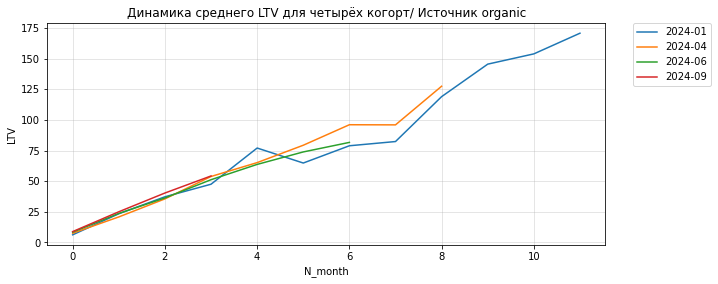

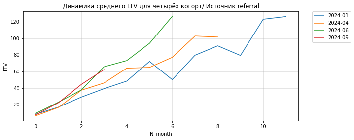

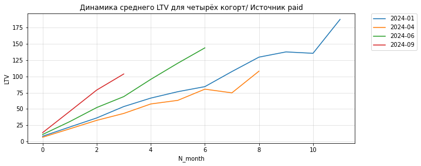

```python
#Устанавливаем размер графика
plt.rcParams['figure.figsize'] = (10, 4)

# Список источников трафика для визуализации
traffic_sources = ['organic', 'referral', 'paid']

# Строим графики для каждого из трёх источников трафика в цикле
for traffic_source in traffic_sources:
    # Фильтруем данные: только для текущего источника трафика
    filtered_data = df_plot.loc[df_plot['traffic_type'] == traffic_source]

    # Проверяем, есть ли данные для этого источника
    if filtered_data.empty:
        display(f"Нет данных для источника: {traffic_source}")
        continue

    # Строим линейный график с маркерами
    ax = sns.lineplot(data= filtered_data, x='n_period', y='LTV', hue='first_activity_month')

    # Задаём дополнительные параметры для лучшего отображения графиков
    #Проверяем, создались ли элементы для легенды, чтобы избежать UserWarning
    handles, labels = ax.get_legend_handles_labels()
    if labels:
        plt.legend(handles=handles, labels=labels, bbox_to_anchor=(1.05, 1), loc='upper left', borderaxespad=0)


    # Устанавливаем названия осей
    plt.xlabel('N_month')
    plt.ylabel('LTV')

    # Устанавливаем заголовок
    plt.title(f'Динамика среднего LTV для четырёх когорт/ Источник {traffic_source}')

    # Добавляем полупрозрачную сетку
    plt.grid(alpha=.4)

    plt.show()
```

#### Визуализация динамики LTV

Используя созданный **df_grouped_ltv**, визуализируем тепловую карту LTV в разрезе двух источников трафика — referral и paid.

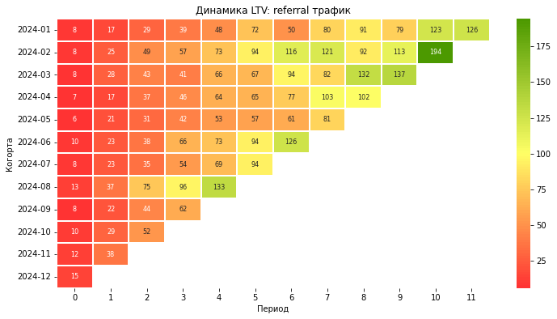

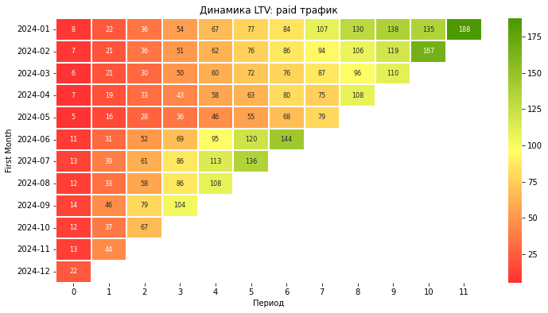

```python
# Устанавливаем размер графика
plt.rcParams['figure.figsize'] = (12, 6)

# Создаём pivot-таблицы для визуализации LTV по типам трафика
# referral-трафик: преобразуем данные в форму 'когорта x период' с заменой нулей на NaN (для наглядности)
df_pivot_referral = df_grouped_ltv[df_grouped_ltv['traffic_type'] == 'referral']
df_pivot_referral = df_pivot_referral.pivot(index='first_activity_month', columns='n_period', values='LTV')
df_pivot_referral[df_pivot_referral == 0] = float('nan')

# paid-трафик: преобразуем данные в форму 'когорта x период' с заменой нулей на NaN (для наглядности)
df_pivot_paid = df_grouped_ltv[df_grouped_ltv['traffic_type'] == 'paid']
df_pivot_paid = df_pivot_paid.pivot(index='first_activity_month', columns='n_period', values='LTV')
df_pivot_paid[df_pivot_paid == 0] = float('nan')

# Строим тепловую карту для трафика referral
sns.heatmap(df_pivot_referral, cmap=cmap, annot=True, fmt='.0f', linewidths=2, annot_kws={"size": 8})
# Добавляем подписи для осей и заголовок графика referral
plt.title('Динамика LTV: referral трафик')
plt.ylabel('Когорта')
plt.xlabel('Период')
plt.show()

# Строим тепловую карту для трафика paid
sns.heatmap(df_pivot_paid, cmap=cmap, annot=True, fmt='.0f', linewidths=2, annot_kws={"size": 8})
# Добавляем подписи для осей и заголовок графика paid
plt.title('Динамика LTV: paid трафик')
plt.xlabel('Период')
plt.ylabel('First Month')
plt.show()
```

### Расчёт CAC

Метрика САС (Customer Acquisition Cost.)- стоимость привлечения одного клиента.

#### Динамика затрат в разрезе источников трафика

Создадим график динамики маркетинговых затрат в разрезе источников трафика за период, представленный в данных.

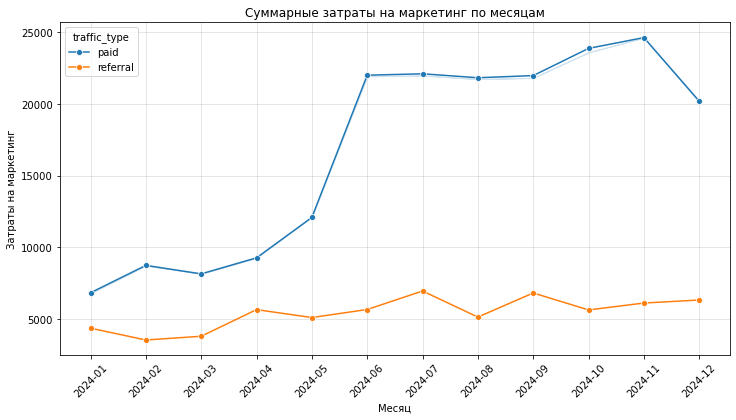

```python
df_marketing_costs['first_activity_month']  = pd.to_datetime(df_marketing_costs['month']).dt.to_period('M')

# Инициализируем фигуру
plt.figure(figsize=(12, 6))

# Строим линейный график маркетинговых затрат для каждого типа трафика
sns.lineplot( data=df_marketing_costs, x= 'month', y='marketing_costs', hue='traffic_type', errorbar=('ci', False), marker='o')

# Оформляем график
plt.grid(alpha=.4)
plt.xticks(rotation=45)

# Добавляем подписи осей
plt.xlabel('Месяц')
plt.ylabel('Затраты на маркетинг')

# Добавляем заголовок
plt.title('Суммарные затраты на маркетинг по месяцам')
plt.show()
```

#### Стоимость привлечения одного клиента (CAC)

Рассчитаем САС - стоимость привлечения одного клиента для комбинации когорты, источника и типа трафика - и добавим в основной аналитический датафрейм **df_monthly**

```python
# Определяем колонки для группировки: когорта, источник и тип трафика
gp_cols = ['first_activity_month', 'source', 'traffic_type']

# Считаем количество уникальных устройств (пользователей) для каждой комбинации: когорта + источник + тип трафика
df_clients_count = df_monthly.groupby(gp_cols)['device_id'].nunique().reset_index()
df_clients_count = df_clients_count.rename(columns={'device_id': 'uniq_devices'})

# Объединяем данные о маркетинговых затратах с количеством пользователей
df_CAC = pd.merge(df_marketing_costs, df_clients_count, on = ['first_activity_month', 'source','traffic_type'], how='left')

# Рассчитываем стоимость привлечения клиента по формуле: CAC = расходы на маркетинг / количество привлечённых пользователей
df_CAC['CAC'] = df_CAC['marketing_costs']/df_CAC['uniq_devices']

# Добавляем колонку CAC в основной датафрейм
df_monthly = pd.merge(df_monthly, df_CAC[['first_activity_month', 'source', 'traffic_type', 'CAC']], on=['first_activity_month', 'source', 'traffic_type'], how='left')
```

```python
df_monthly.head()
```

|  | device_id | activity_month | first_activity_month | session_id | total_revenue | traffic_type | source | n_period | LTV | CAC |
| --- | --- | --- | --- | --- | --- | --- | --- | --- | --- | --- |
| 0 | 0000614f-d87f-4b5b-a082-d86e72c22696 | 2024-07 | 2024-07 | 9 | 0.0 | paid | google | 0 | 0.0 | 75.296296 |
| 1 | 0000614f-d87f-4b5b-a082-d86e72c22696 | 2024-08 | 2024-07 | 5 | 0.0 | paid | google | 1 | 0.0 | 75.296296 |
| 2 | 0000614f-d87f-4b5b-a082-d86e72c22696 | 2024-11 | 2024-07 | 4 | 0.0 | paid | google | 4 | 0.0 | 75.296296 |
| 3 | 0000614f-d87f-4b5b-a082-d86e72c22696 | 2024-12 | 2024-07 | 18 | 25.0 | paid | google | 5 | 25.0 | 75.296296 |
| 4 | 00010045-a5c6-4428-a40e-543f6a00c779 | 2024-09 | 2024-09 | 10 | 0.0 | paid | tiktok | 0 | 0.0 | 284.411765 |

#### Визуализация динамики среднего CAC по типам трафика

Визуализируем динамику средней стоимости привлечения клиента (CAC) по типам трафика в разрезе месяцев.

```python
# Группируем данные по когорте (месяц первой активности) и типу трафика — рассчитываем средний CAC для каждой группы
cac_grouped = df_monthly.groupby(['first_activity_month', 'traffic_type'])['CAC'].mean().reset_index()
```

```python
cac_grouped.head()
```

|  | first_activity_month | traffic_type | CAC |
| --- | --- | --- | --- |
| 0 | 2024-01 | organic | NaN |
| 1 | 2024-01 | paid | 71.548258 |
| 2 | 2024-01 | referral | 30.510490 |
| 3 | 2024-02 | organic | NaN |
| 4 | 2024-02 | paid | 74.603902 |

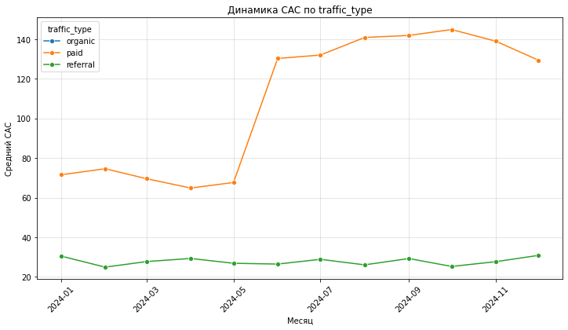

```python
# Инициализируем холст для графика
plt.figure(figsize=(12, 6))
# Строим линейный график с разделением по типам трафика
ax=sns.lineplot(
    data=cac_grouped.assign(first_activity_month=cac_grouped['first_activity_month'].dt.to_timestamp()), # для корректной работы с осью времени
    x='first_activity_month', y='CAC', hue='traffic_type', errorbar=('ci', False), marker='o')
# Настраиваем отображение подписей
plt.xticks(rotation=45)
plt.grid(alpha=.4)
# Добавляем подписи осей
plt.xlabel('Месяц')
plt.ylabel('Средний CAC')
# Добавляем заголовок
plt.title('Динамика CAC по traffic_type')
plt.show()
```

### Расчёт Payback Period

Payback Period (период окупаемости) — это время, за которое доход от когорты сравнивается с затратами на её привлечение. В маркетинге это момент, когда LTV становится равен CAC (или ROI выходит в 0).

#### Подготовка вспомогательного датафрейма

Создадим вспомогательный датафрейм cac_ltv_grouped - в нём проведём предварительную фильтрацию и агрегацию данных, рассчитав средние значения LTV и CAC для каждой когорты платного трафика. В результате должен получиться датафрейм **cac_ltv_grouped** с такими колонками:

- first_activity_month,
- n_period,
- LTV — среднее значение LTV для когорты и периода,
- CAC — среднее значение CAC для когорты и периода.

```python
# Из основной таблицы выберем только значения для платного трафика
df_monthly_paid = df_monthly.loc[df_monthly['traffic_type'] == 'paid']

# Для каждой когорты и канала посчитаем среднее значение LTV, CAC
cac_ltv_grouped = df_monthly_paid.groupby(['first_activity_month','n_period']).agg({
    'LTV' : 'mean',
    'CAC' : 'mean' }).reset_index()
```

```python
cac_ltv_grouped.head()
```

|  | first_activity_month | n_period | LTV | CAC |
| --- | --- | --- | --- | --- |
| 0 | 2024-01 | 0 | 8.131399 | 71.493827 |
| 1 | 2024-01 | 1 | 22.216867 | 71.649327 |
| 2 | 2024-01 | 2 | 36.205955 | 71.732369 |
| 3 | 2024-01 | 3 | 53.670918 | 71.294831 |
| 4 | 2024-01 | 4 | 66.690176 | 71.619551 |

#### Визуализация среднего LTV и CAC по когортам

Визуализирем изменения в LTV и средней стоимости привлечения клиентов (CAC) для когорт пользователей, которые привлечены через платный трафик. Для сравнения выберем несколько когорт в начале и конце периода.

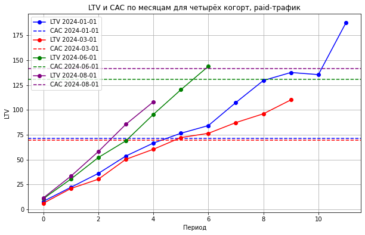

```python
# Словарь с когортами и соответствующими им цветами
first_months_colors = {'2024-01-01': 'blue', '2024-03-01': 'red', '2024-06-01': 'green', '2024-08-01': 'purple'}

# Создаём график
plt.figure(figsize=(10, 6))

# Строим линии для каждого first_activity_month (когорты)
for month, color in first_months_colors.items():
    # Создаём отфильтрованный датафрейм для текущей когорты
    df_plot = cac_ltv_grouped.loc[cac_ltv_grouped['first_activity_month'] == month].sort_values('n_period')

    # Строим LTV с цветом из словаря
    plt.plot(df_plot['n_period'],
        df_plot['LTV'],
        color=color,
        marker='o',
        label=f'LTV {month}'
    )

    # Строим линию для CAC с тем же цветом
    cac_value = df_plot['CAC'].mean()
    plt.axhline(
        y=cac_value,
        color=color,
        linestyle='--',
        label=f'CAC {month}'
    )

# Добавляем заголовок
plt.title('LTV и CAC по месяцам для четырёх когорт, paid-трафик')
# Добавляем подписи осей
plt.xlabel('Период')
plt.ylabel('LTV')
# Добавляем легенду
plt.legend()
# Добавляем сетку
plt.grid(True)
plt.show()
```

#### Вывод

1. Для когорт второй половины года наблюдается ускоренный рост LTV, при этом значительно вырос CAC.
2. Срок окупаемости мартовской когорты немного выше, чем у январской.
3. Если продлить линию LTV для когорт второй половины года и оценить их Payback Period, он будет совсем немного отличаться от когорт первой половины года и находится в промежутке от четырёх с половиной до пяти с половиной месяцев.

### Расчёт ROI

ROI (Return on Investment) — это коэффициент окупаемости инвестиций.

#### Визуализация ROI для когорт пользователей

Визуализируем динамику ROI для выбранных когорт пользователей и границу окупаемости затрат для выбранных ранее когорт.

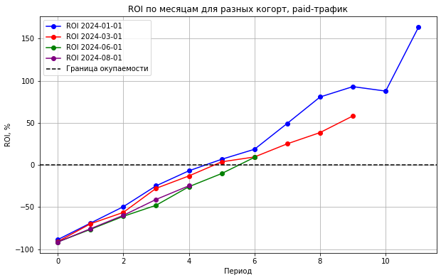

```python
# Словарь с когортами и соответствующими им цветами
first_months_colors = {'2024-01-01': 'blue', '2024-03-01': 'red', '2024-06-01': 'green', '2024-08-01': 'purple'}

# Рассчитываем ROI для каждой когорты и периода
cac_ltv_grouped['ROI'] = (cac_ltv_grouped['LTV'] - cac_ltv_grouped['CAC'])/cac_ltv_grouped['CAC'] *100

# Создаём график
plt.figure(figsize=(10, 6))

# Строим линии для каждого first_activity_month (когорты)
for month, color in first_months_colors.items():
    # Создаём промежуточный отфильтрованный датафрейм для текущей когорты
    df_plot = cac_ltv_grouped.loc[cac_ltv_grouped['first_activity_month'] == month]

    # Строим динамику ROI по периодам с цветами из словаря
    plt.plot(df_plot['n_period'], df_plot['ROI'], color=color, marker='o', label=f'ROI {month}' )

# Добавляем горизонтальную линию — границу окупаемости
plt.axhline(y=0, color='black', linestyle='--', label='Граница окупаемости')

# Добавляем заголовок
plt.title('ROI по месяцам для разных когорт, paid-трафик')
# Добавляем подписи осей
plt.xlabel('Период')
plt.ylabel('ROI, %')
# Добавляем легенду
plt.legend()
# Добавляем сетку
plt.grid(True)
plt.show()
```

#### Визуализация ROI в виде тепловой карты

Создадим тепловую карту для анализа ROI в разрезе когорт и периодов. Она позволит быстро сравнить эффективность инвестиций.

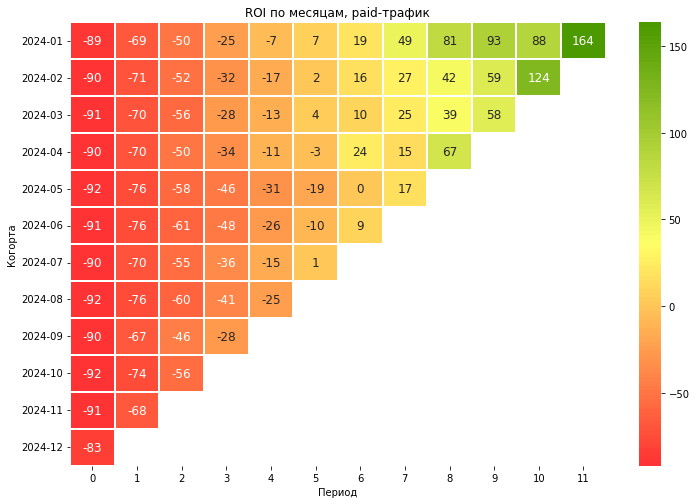

```python
cmap = mcolors.LinearSegmentedColormap.from_list('green_red', ['#FF3333', '#FFFF66', '#4C9900'], N=100)

# Пивотируем данные, чтобы first_activity_month были индексами, а n_period — столбцами
# pivot для LTV
df_pivot_ltv = cac_ltv_grouped.pivot(index='first_activity_month', columns='n_period', values='LTV')

# pivot для CAC
df_pivot_cac = cac_ltv_grouped.pivot(index='first_activity_month', columns='n_period', values='CAC')

# Расчёт матрицы ROI на основе пивотированных таблиц LTV и CAC
df_pivot_roi = (df_pivot_ltv - df_pivot_cac)/df_pivot_cac *100

# Заменяем нули в df_pivot_roi на NaN для корректной отрисовки
df_pivot_roi[df_pivot_roi == 0] = float('nan')

# Создаём график
plt.figure(figsize=(12, 8))

# Строим heatmap с палитрой
sns.heatmap(df_pivot_roi, cmap=cmap, annot=True, fmt='.0f', linewidths=2, annot_kws={"size": 12})

# Добавляем заголовок
plt.title('ROI по месяцам, paid-трафик')

# Добавляем подписи осей
plt.xlabel('Период')
plt.ylabel('Когорта')
plt.show()
```

### Расчёт и визуализация ARPPU

ARPPU (Average Revenue Per Paying User) - средний доход на одного платящего пользователя за определенный период.

Анализ этой метрики позволит понять, насколько эффективно монетизируются пользователи приложения из платящего трафика. Для визуализации построим тепловую карту. Она позволит проанализировать средний доход с платящего пользователя в разрезе когорт и периодов.

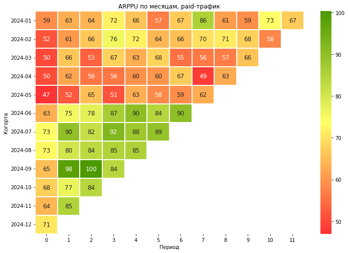

```python
df_monthly_paid = df_monthly[df_monthly['traffic_type'] == 'paid']

# pivot для суммарной выручки по когортам и периодам
df_pivot_sum_revenue = pd.pivot_table(df_monthly_paid, index='first_activity_month',
                                      columns='n_period', values='total_revenue', aggfunc='sum')

# pivot для количества платящих пользователей (уникальные device_id с revenue > 0)
df_pivot_paying_users = df_monthly_paid.loc[df_monthly_paid['total_revenue'] > 0]
df_pivot_paying_users = pd.pivot_table(df_pivot_paying_users, index='first_activity_month',
                                       columns='n_period', values='device_id', aggfunc='nunique')

# Рассчитываем ARPPU и очищаем данные
df_pivot_arppu = df_pivot_sum_revenue/df_pivot_paying_users

# Создаём график
plt.figure(figsize=(12, 8))

# Строим heatmap ARPPU с палитрой
sns.heatmap(df_pivot_arppu, cmap=cmap, annot=True, fmt='.0f', linewidths=2, annot_kws={"size": 12})

# Добавляем заголовок
plt.title('ARPPU по месяцам, paid-трафик')

# Добавляем подписи осей
plt.xlabel('Период')
plt.ylabel('Когорта')
plt.show()
```

#### Вывод

Рост ARPPU во второй половине года говорит о том, что продукт стал лучше зарабатывать на одном клиенте.

### Расчёт и визуализация Retention Rate

Retention Rate (RR) — ключевой индикатор лояльности пользователей. Для визуализации RR построим тепловую карту для платного трафика. Она позволит оценить динамику метрики в разрезе когорт и периодов.

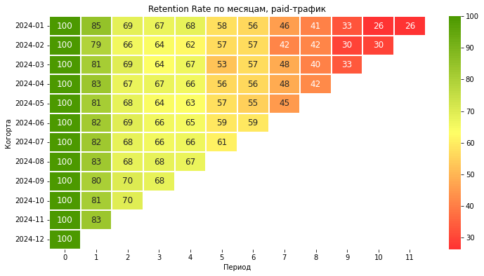

```python
df_monthly_paid = df_monthly[df_monthly['traffic_type'] == 'paid']

# Создаём сводную таблицу активных пользователей из платного трафика
df_pivot_active_users = pd.pivot_table(df_monthly_paid, index='first_activity_month',
                                       columns='n_period', values='device_id', aggfunc='nunique')

# Рассчитываем Retention Rate (%)
df_pivot_retention = df_pivot_active_users.div(df_pivot_active_users[0], axis=0)*100

# Создаём график
plt.figure(figsize=(12, 6))
# Строим heatmap Retention Rate с палитрой

sns.heatmap(df_pivot_retention, cmap=cmap, annot=True, fmt='.0f', linewidths=2, annot_kws={"size": 12})
# Добавляем заголовок
plt.title('Retention Rate по месяцам, paid-трафик')
# Добавляем подписи осей
plt.xlabel('Период')
plt.ylabel('Когорта')
plt.show()
```

#### Вывод:

Т.к. Retention Ratr стабилен при росте ARPPU, подтверждает, что привлечена качественная (хоть и дорогая) аудитория.

## Общий вывод и рекомендации

В проекте рассчитаны, проанализированы и визуализированы ключевые бизнес-метрики юнит-экономики игрового мобильного приложения.

Направление основных метрик:

- Негативное изменение: САС,
- Практически без изменений: Payback Period, ROI, Retention Rate,
- Положительное изменение: LTV, ARPPU.

Состояние юнит-экономики можно описать как эффект удорожания масштабирования при сохранении качества продукта. Юнит-экономика находится в состоянии неустойчивого равновесия.

**Позитивные тенденции:**

- Рост LTV и ARPPU говорит о том, что продукт стал лучше зарабатывать на одном клиенте. Те, кто приходят, платят больше (растет средний чек или частота покупок). Это отличный знак — «ядро» продукта работает эффективно.
- Текущая модель окупаема и стабильна - Payback Period и ROI не меняются, т.к. происходит взаимная компенсация LTV и CAC.

**Риск:**

- Рост CAC (негативное изменение) означает, что каждый новый пользователь обходится всё дороже. Рекламные каналы перегреты, или привлекается менее лояльная аудиторию, за которую приходится бороться. Если CAC продолжит расти быстрее, чем LTV, юнит-экономика станет отрицательной (ROI пойдет вниз, окупаемость затянется).

**Вывод:** Эффективность вложений не падает, но и не растет. Бизнес «бежит со всех ног, чтобы оставаться на месте»(с).

**Рекомендации бизнесу**:

1. Срочно искать новые, более дешевые каналы трафика, так как текущие становятся слишком дорогими.
2. Или продолжить инвестиции в платный трафик, но оптимизировать таргетинг для привлечения более ценной аудитории и снижения CAC.
3. Провести эксперименты по дальнейшему увеличению LTV, чтобы создать «запас прочности» против растущего CAC.
4. Рост LTV позволит масштабироваться при условии контроля за затратами.